# Case study 1 - R script

Igor Angelovskiy

05 11 2021

### Scenario

We work as a part of the marketing team at Cyclistic, a bike-share company in Chicago. The director of marketing believes the company’s future success depends on maximizing the number of annual memberships. Therefore, marketing team wants to understand how casual riders and annual members use Cyclistic bikes differently. From these insights, the team will design a new marketing strategy to convert casual riders into annual members. But first, Cyclistic executives must approve our recommendations, so they must be backed up with compelling data insights and professional data visualizations.

### Characters and teams

- **Cyclistic**: A bike-share program that features more than 5,800 bicycles and 600 docking stations. Cyclistic sets itself apart by also offering reclining bikes, hand tricycles, and cargo bikes, making bike-share more inclusive to people with disabilities and riders who can’t use a standard two-wheeled bike. The majority of riders opt for traditional bikes; about 8% of riders use the assistive options. Cyclistic users are more likely to ride for leisure, but about 30% use them to commute to work each day.
- **Lily Moreno**: The director of marketing and our manager. Moreno is responsible for the development of campaigns and initiatives to promote the bike-share program. These may include email, social media, and other channels.
- **Cyclistic marketing analytics team**: A team of data analysts who are responsible for collecting, analyzing, and reporting data that helps guide Cyclistic marketing strategy.
- **Cyclistic executive team**: The notoriously detail-oriented executive team will decide whether to approve the recommended marketing program.

### Process and Analize stages of data analysis

Load required packages: * Data import and data wrangling - tidyverse * Date functions - lubridate * Data visualization - ggplot2

```r
library(tidyverse)
library(lubridate)
```

```r
library(ggplot2)
```

Let’s check what working directory is used.

```r
getwd()
```

```
## [1] "C:/Users/angel/Documents/Environmental/Data_Analytics/Case_Study/Case_Study_1/Case_Study_1_Data/trip_data_csv"
```

Let’s change it to the new working directory to avoid errors and simplify calls to data.

```r
setwd("/Users/angel/Documents/Environmental/Data_Analytics/Case_Study/Case_Study_1/Case_Study_1_Data/trip_data_csv")
```

#### **Step 1 - Collecting data**

Upload data (csv files)

```r
trips_2019_q2 <- read_csv("Divvy_Trips_2019_Q2.csv")
trips_2019_q3 <- read_csv("Divvy_Trips_2019_Q3.csv")
trips_2019_q4 <- read_csv("Divvy_Trips_2019_Q4.csv")
trips_2020_q1 <- read_csv("Divvy_Trips_2020_Q1.csv")
```

#### **Step 2 - Wrangling data and combining it into one single file**

Let’s compare column names in each file

```r
colnames(trips_2019_q2)
```

```
##  [1] "01 - Rental Details Rental ID"
##  [2] "01 - Rental Details Local Start Time"
##  [3] "01 - Rental Details Local End Time"
##  [4] "01 - Rental Details Bike ID"
##  [5] "01 - Rental Details Duration In Seconds Uncapped"
##  [6] "03 - Rental Start Station ID"
##  [7] "03 - Rental Start Station Name"
##  [8] "02 - Rental End Station ID"
##  [9] "02 - Rental End Station Name"
## [10] "User Type"
## [11] "Member Gender"
## [12] "05 - Member Details Member Birthday Year"
```

```r
colnames(trips_2019_q3)
```

```
##  [1] "trip_id"           "start_time"        "end_time"
##  [4] "bikeid"            "tripduration"      "from_station_id"
##  [7] "from_station_name" "to_station_id"     "to_station_name"
## [10] "usertype"          "gender"            "birthyear"
```

```r
colnames(trips_2019_q4)
```

```
##  [1] "trip_id"           "start_time"        "end_time"
##  [4] "bikeid"            "tripduration"      "from_station_id"
##  [7] "from_station_name" "to_station_id"     "to_station_name"
## [10] "usertype"          "gender"            "birthyear"
```

```r
colnames(trips_2020_q1)
```

```
##  [1] "ride_id"            "rideable_type"      "started_at"
##  [4] "ended_at"           "start_station_name" "start_station_id"
##  [7] "end_station_name"   "end_station_id"     "start_lat"
## [10] "start_lng"          "end_lat"            "end_lng"
## [13] "member_casual"
```

As we can see column names are not consistent in this files. So before creating one single file we need to rename column names to be matching with trips_2020_q1.

```r
trips_2019_q4 <- rename(trips_2019_q4,
                       ride_id = trip_id,
                       rideable_type = bikeid,
                       started_at = start_time,
                       ended_at = end_time,
                       start_station_name = from_station_name,
                       start_station_id = from_station_id,
                       end_station_name = to_station_name,
                       end_station_id = to_station_id,
                       member_casual = usertype)

trips_2019_q3 <- rename(trips_2019_q3,
                        ride_id = trip_id,
                        rideable_type = bikeid,
                        started_at = start_time,
                        ended_at = end_time,
                        start_station_name = from_station_name,
                        start_station_id = from_station_id,
                        end_station_name = to_station_name,
                        end_station_id = to_station_id,
                        member_casual = usertype)

trips_2019_q2 <- rename(trips_2019_q2,
                        ride_id = "01 - Rental Details Rental ID",
                        rideable_type = "01 - Rental Details Bike ID",
                        started_at = "01 - Rental Details Local Start Time",
                        ended_at = "01 - Rental Details Local End Time",
                        start_station_name = "03 - Rental Start Station Name",
                        start_station_id = "03 - Rental Start Station ID",
                        end_station_name = "02 - Rental End Station Name",
                        end_station_id = "02 - Rental End Station ID",
                        member_casual = "User Type")
```

Let’s check the structure of the data in tables:

```r
str(trips_2019_q2)
```

```
## spec_tbl_df [1,108,163 x 12] (S3: spec_tbl_df/tbl_df/tbl/data.frame)
##  $ ride_id                                         : num [1:1108163] 22178529 22178530 22178531 22178532 22178533 ...
##  $ started_at                                      : POSIXct[1:1108163], format: "2019-04-01 00:02:22" "2019-04-01 00:03:02" ...
##  $ ended_at                                        : POSIXct[1:1108163], format: "2019-04-01 00:09:48" "2019-04-01 00:20:30" ...
##  $ rideable_type                                   : num [1:1108163] 6251 6226 5649 4151 3270 ...
##  $ 01 - Rental Details Duration In Seconds Uncapped: num [1:1108163] 446 1048 252 357 1007 ...
##  $ start_station_id                                : num [1:1108163] 81 317 283 26 202 420 503 260 211 211 ...
##  $ start_station_name                              : chr [1:1108163] "Daley Center Plaza" "Wood St & Taylor St" "LaSalle St & Jackson Blvd" "McClurg Ct & Illinois St" ...
##  $ end_station_id                                  : num [1:1108163] 56 59 174 133 129 426 500 499 211 211 ...
##  $ end_station_name                                : chr [1:1108163] "Desplaines St & Kinzie St" "Wabash Ave & Roosevelt Rd" "Canal St & Madison St" "Kingsbury St & Kinzie St" ...
##  $ member_casual                                   : chr [1:1108163] "Subscriber" "Subscriber" "Subscriber" "Subscriber" ...
##  $ Member Gender                                   : chr [1:1108163] "Male" "Female" "Male" "Male" ...
##  $ 05 - Member Details Member Birthday Year        : num [1:1108163] 1975 1984 1990 1993 1992 ...
##  - attr(*, "spec")=
##   .. cols(
##   ..   `01 - Rental Details Rental ID` = col_double(),
##   ..   `01 - Rental Details Local Start Time` = col_datetime(format = ""),
##   ..   `01 - Rental Details Local End Time` = col_datetime(format = ""),
##   ..   `01 - Rental Details Bike ID` = col_double(),
##   ..   `01 - Rental Details Duration In Seconds Uncapped` = col_number(),
##   ..   `03 - Rental Start Station ID` = col_double(),
##   ..   `03 - Rental Start Station Name` = col_character(),
##   ..   `02 - Rental End Station ID` = col_double(),
##   ..   `02 - Rental End Station Name` = col_character(),
##   ..   `User Type` = col_character(),
##   ..   `Member Gender` = col_character(),
##   ..   `05 - Member Details Member Birthday Year` = col_double()
##   .. )
##  - attr(*, "problems")=<externalptr>
```

```r
str(trips_2019_q3)
```

```
## spec_tbl_df [1,640,718 x 12] (S3: spec_tbl_df/tbl_df/tbl/data.frame)
##  $ ride_id           : num [1:1640718] 23479388 23479389 23479390 23479391 23479392 ...
##  $ started_at        : POSIXct[1:1640718], format: "2019-07-01 00:00:27" "2019-07-01 00:01:16" ...
##  $ ended_at          : POSIXct[1:1640718], format: "2019-07-01 00:20:41" "2019-07-01 00:18:44" ...
##  $ rideable_type     : num [1:1640718] 3591 5353 6180 5540 6014 ...
##  $ tripduration      : num [1:1640718] 1214 1048 1554 1503 1213 ...
##  $ start_station_id  : num [1:1640718] 117 381 313 313 168 300 168 313 43 43 ...
##  $ start_station_name: chr [1:1640718] "Wilton Ave & Belmont Ave" "Western Ave & Monroe St" "Lakeview Ave & Fullerton Pkwy" "Lakeview Ave & Fullerton Pkwy" ...
##  $ end_station_id    : num [1:1640718] 497 203 144 144 62 232 62 144 195 195 ...
##  $ end_station_name  : chr [1:1640718] "Kimball Ave & Belmont Ave" "Western Ave & 21st St" "Larrabee St & Webster Ave" "Larrabee St & Webster Ave" ...
##  $ member_casual     : chr [1:1640718] "Subscriber" "Customer" "Customer" "Customer" ...
##  $ gender            : chr [1:1640718] "Male" NA NA NA ...
##  $ birthyear         : num [1:1640718] 1992 NA NA NA NA ...
##  - attr(*, "spec")=
##   .. cols(
##   ..   trip_id = col_double(),
##   ..   start_time = col_datetime(format = ""),
##   ..   end_time = col_datetime(format = ""),
##   ..   bikeid = col_double(),
##   ..   tripduration = col_number(),
##   ..   from_station_id = col_double(),
##   ..   from_station_name = col_character(),
##   ..   to_station_id = col_double(),
##   ..   to_station_name = col_character(),
##   ..   usertype = col_character(),
##   ..   gender = col_character(),
##   ..   birthyear = col_double()
##   .. )
##  - attr(*, "problems")=<externalptr>
```

```r
str(trips_2019_q4)
```

```
## spec_tbl_df [704,054 x 12] (S3: spec_tbl_df/tbl_df/tbl/data.frame)
##  $ ride_id           : num [1:704054] 25223640 25223641 25223642 25223643 25223644 ...
##  $ started_at        : POSIXct[1:704054], format: "2019-10-01 00:01:39" "2019-10-01 00:02:16" ...
##  $ ended_at          : POSIXct[1:704054], format: "2019-10-01 00:17:20" "2019-10-01 00:06:34" ...
##  $ rideable_type     : num [1:704054] 2215 6328 3003 3275 5294 ...
##  $ tripduration      : num [1:704054] 940 258 850 2350 1867 ...
##  $ start_station_id  : num [1:704054] 20 19 84 313 210 156 84 156 156 336 ...
##  $ start_station_name: chr [1:704054] "Sheffield Ave & Kingsbury St" "Throop (Loomis) St & Taylor St" "Milwaukee Ave & Grand Ave" "Lakeview Ave & Fullerton Pkwy" ...
##  $ end_station_id    : num [1:704054] 309 241 199 290 382 226 142 463 463 336 ...
##  $ end_station_name  : chr [1:704054] "Leavitt St & Armitage Ave" "Morgan St & Polk St" "Wabash Ave & Grand Ave" "Kedzie Ave & Palmer Ct" ...
##  $ member_casual     : chr [1:704054] "Subscriber" "Subscriber" "Subscriber" "Subscriber" ...
##  $ gender            : chr [1:704054] "Male" "Male" "Female" "Male" ...
##  $ birthyear         : num [1:704054] 1987 1998 1991 1990 1987 ...
##  - attr(*, "spec")=
##   .. cols(
##   ..   trip_id = col_double(),
##   ..   start_time = col_datetime(format = ""),
##   ..   end_time = col_datetime(format = ""),
##   ..   bikeid = col_double(),
##   ..   tripduration = col_number(),
##   ..   from_station_id = col_double(),
##   ..   from_station_name = col_character(),
##   ..   to_station_id = col_double(),
##   ..   to_station_name = col_character(),
##   ..   usertype = col_character(),
##   ..   gender = col_character(),
##   ..   birthyear = col_double()
##   .. )
##  - attr(*, "problems")=<externalptr>
```

```r
str(trips_2020_q1)
```

```
## spec_tbl_df [426,887 x 13] (S3: spec_tbl_df/tbl_df/tbl/data.frame)
##  $ ride_id           : chr [1:426887] "EACB19130B0CDA4A" "8FED874C809DC021" "789F3C21E472CA96" "C9A388DAC6ABF313" ...
##  $ rideable_type     : chr [1:426887] "docked_bike" "docked_bike" "docked_bike" "docked_bike" ...
##  $ started_at        : POSIXct[1:426887], format: "2020-01-21 20:06:59" "2020-01-30 14:22:39" ...
##  $ ended_at          : POSIXct[1:426887], format: "2020-01-21 20:14:30" "2020-01-30 14:26:22" ...
##  $ start_station_name: chr [1:426887] "Western Ave & Leland Ave" "Clark St & Montrose Ave" "Broadway & Belmont Ave" "Clark St & Randolph St" ...
##  $ start_station_id  : num [1:426887] 239 234 296 51 66 212 96 96 212 38 ...
##  $ end_station_name  : chr [1:426887] "Clark St & Leland Ave" "Southport Ave & Irving Park Rd" "Wilton Ave & Belmont Ave" "Fairbanks Ct & Grand Ave" ...
##  $ end_station_id    : num [1:426887] 326 318 117 24 212 96 212 212 96 100 ...
##  $ start_lat         : num [1:426887] 42 42 41.9 41.9 41.9 ...
##  $ start_lng         : num [1:426887] -87.7 -87.7 -87.6 -87.6 -87.6 ...
##  $ end_lat           : num [1:426887] 42 42 41.9 41.9 41.9 ...
##  $ end_lng           : num [1:426887] -87.7 -87.7 -87.7 -87.6 -87.6 ...
##  $ member_casual     : chr [1:426887] "member" "member" "member" "member" ...
##  - attr(*, "spec")=
##   .. cols(
##   ..   ride_id = col_character(),
##   ..   rideable_type = col_character(),
##   ..   started_at = col_datetime(format = ""),
##   ..   ended_at = col_datetime(format = ""),
##   ..   start_station_name = col_character(),
##   ..   start_station_id = col_double(),
##   ..   end_station_name = col_character(),
##   ..   end_station_id = col_double(),
##   ..   start_lat = col_double(),
##   ..   start_lng = col_double(),
##   ..   end_lat = col_double(),
##   ..   end_lng = col_double(),
##   ..   member_casual = col_character()
##   .. )
##  - attr(*, "problems")=<externalptr>
```

As we can see ride_id and rideable_type are characters in trips_2020_q1. Let’s convert corresponding columns in the rest of the files, so the data can be stacked correctly.

```r
trips_2019_q2 <- mutate(trips_2019_q2,
                        ride_id = as.character(ride_id),
                        rideable_type =as.character(rideable_type))

trips_2019_q3 <- mutate(trips_2019_q3,
                        ride_id = as.character(ride_id),
                        rideable_type =as.character(rideable_type))

trips_2019_q4 <- mutate(trips_2019_q4,
                        ride_id = as.character(ride_id),
                        rideable_type =as.character(rideable_type))
```

Let’s stack individual quarter’s data into one single file (this could take some time).

```r
all_trips <- bind_rows(trips_2019_q2, trips_2019_q3, trips_2019_q4, trips_2020_q1)
```

Now let’s check what column names are present in all_trips.

```r
colnames(all_trips)
```

```
##  [1] "ride_id"
##  [2] "started_at"
##  [3] "ended_at"
##  [4] "rideable_type"
##  [5] "01 - Rental Details Duration In Seconds Uncapped"
##  [6] "start_station_id"
##  [7] "start_station_name"
##  [8] "end_station_id"
##  [9] "end_station_name"
## [10] "member_casual"
## [11] "Member Gender"
## [12] "05 - Member Details Member Birthday Year"
## [13] "tripduration"
## [14] "gender"
## [15] "birthyear"
## [16] "start_lat"
## [17] "start_lng"
## [18] "end_lat"
## [19] "end_lng"
```

We see a few columns with data that is inconsistent through out the year. We remove them from all_trips (using pipes).

```r
all_trips <- all_trips %>%
  select(-c("01 - Rental Details Duration In Seconds Uncapped",
            "Member Gender",
            "05 - Member Details Member Birthday Year",
            "tripduration",
            "gender",
            "birthyear",
            "start_lat",
            "start_lng",
            "end_lat",
            "end_lng"))
```

Let’s check that everything is correct.

```r
colnames(all_trips)
```

```
## [1] "ride_id"            "started_at"         "ended_at"
## [4] "rideable_type"      "start_station_id"   "start_station_name"
## [7] "end_station_id"     "end_station_name"   "member_casual"
```

All changes are correct and we can move to the next step.

#### **Step 3 - Cleaning, addding data to prepare for analysis**

Let’s inspect new table.

```r
nrow(all_trips) # number of rows in the table
```

```
## [1] 3879822
```

```r
dim(all_trips) # dimensions of the data frame
```

```
## [1] 3879822       9
```

```r
head(all_trips) # first 6 rows of the data frame
```

```
## # A tibble: 6 x 9
##   ride_id started_at          ended_at            rideable_type start_station_id
##   <chr>   <dttm>              <dttm>              <chr>                    <dbl>
## 1 221785~ 2019-04-01 00:02:22 2019-04-01 00:09:48 6251                        81
## 2 221785~ 2019-04-01 00:03:02 2019-04-01 00:20:30 6226                       317
## 3 221785~ 2019-04-01 00:11:07 2019-04-01 00:15:19 5649                       283
## 4 221785~ 2019-04-01 00:13:01 2019-04-01 00:18:58 4151                        26
## 5 221785~ 2019-04-01 00:19:26 2019-04-01 00:36:13 3270                       202
## 6 221785~ 2019-04-01 00:19:39 2019-04-01 00:23:56 3123                       420
## # ... with 4 more variables: start_station_name <chr>, end_station_id <dbl>,
## #   end_station_name <chr>, member_casual <chr>
```

Let’s check what values are present in member_casual column.

```r
table(all_trips$member_casual)
```

```
##
##     casual   Customer     member Subscriber
##      48480     857474     378407    2595461
```

**Problems to be fixed:** 1. In the column member_casual there are 2 names for members (“Subscriber”, “member”) and 2 names for casual riders (“Customer”, “casual”). Reassign to desired values (using pipes).

```r
all_trips <- all_trips %>%
  mutate(member_casual = recode(member_casual, "Subscriber" = "member", "Customer" = "casual"))
```

Let’s check that all changes were successful.

```r
table(all_trips$member_casual)
```

```
##
##  casual  member
##  905954 2973868
```

2. We need to add some additional columns: date, year, month, day, day_of_week. It will provide us more opportunities to aggregate data.

```r
all_trips$date <- as.Date(all_trips$started_at)
# added column "date"
all_trips$year <- year(all_trips$date)
# added the column "year"
all_trips$month <- month(all_trips$date)
# added the column "month"
all_trips$day <- day(all_trips$date)
# added the column "day"
all_trips$day_of_week <- wday(all_trips$date, label=FALSE)
# added the column "day_of_week"
all_trips <- all_trips %>%
  mutate(day_of_week = recode(day_of_week, "1" = "Sunday", "2" = "Monday", "3" = "Tuesday", "4" = "Wednesday", "5" = "Thursday", "6" = "Friday", "7" = "Saturday"))
```

Check if all changes were successful.

```r
glimpse(all_trips)
```

```
## Rows: 3,879,822
## Columns: 14
## $ ride_id            <chr> "22178529", "22178530", "22178531", "22178532", "22~
## $ started_at         <dttm> 2019-04-01 00:02:22, 2019-04-01 00:03:02, 2019-04-~
## $ ended_at           <dttm> 2019-04-01 00:09:48, 2019-04-01 00:20:30, 2019-04-~
## $ rideable_type      <chr> "6251", "6226", "5649", "4151", "3270", "3123", "64~
## $ start_station_id   <dbl> 81, 317, 283, 26, 202, 420, 503, 260, 211, 211, 304~
## $ start_station_name <chr> "Daley Center Plaza", "Wood St & Taylor St", "LaSal~
## $ end_station_id     <dbl> 56, 59, 174, 133, 129, 426, 500, 499, 211, 211, 232~
## $ end_station_name   <chr> "Desplaines St & Kinzie St", "Wabash Ave & Roosevel~
## $ member_casual      <chr> "member", "member", "member", "member", "member", "~
## $ date               <date> 2019-04-01, 2019-04-01, 2019-04-01, 2019-04-01, 20~
## $ year               <dbl> 2019, 2019, 2019, 2019, 2019, 2019, 2019, 2019, 201~
## $ month              <dbl> 4, 4, 4, 4, 4, 4, 4, 4, 4, 4, 4, 4, 4, 4, 4, 4, 4, ~
## $ day                <int> 1, 1, 1, 1, 1, 1, 1, 1, 1, 1, 1, 1, 1, 1, 1, 1, 1, ~
## $ day_of_week        <chr> "Monday", "Monday", "Monday", "Monday", "Monday", "~
```

3. We need to calculate duration of each ride (difference between ended_at and started_at)

```r
all_trips$ride_length <- difftime(all_trips$ended_at, all_trips$started_at)
```

```r
is.factor(all_trips$ride_length)
```

```
## [1] FALSE
```

```r
all_trips$ride_length <- as.numeric(as.character(all_trips$ride_length))
is.numeric(all_trips$ride_length)
```

```
## [1] TRUE
```

Let’s check what we got after calculations.

```r
str(all_trips)
```

```
## tibble [3,879,822 x 15] (S3: tbl_df/tbl/data.frame)
##  $ ride_id           : chr [1:3879822] "22178529" "22178530" "22178531" "22178532" ...
##  $ started_at        : POSIXct[1:3879822], format: "2019-04-01 00:02:22" "2019-04-01 00:03:02" ...
##  $ ended_at          : POSIXct[1:3879822], format: "2019-04-01 00:09:48" "2019-04-01 00:20:30" ...
##  $ rideable_type     : chr [1:3879822] "6251" "6226" "5649" "4151" ...
##  $ start_station_id  : num [1:3879822] 81 317 283 26 202 420 503 260 211 211 ...
##  $ start_station_name: chr [1:3879822] "Daley Center Plaza" "Wood St & Taylor St" "LaSalle St & Jackson Blvd" "McClurg Ct & Illinois St" ...
##  $ end_station_id    : num [1:3879822] 56 59 174 133 129 426 500 499 211 211 ...
##  $ end_station_name  : chr [1:3879822] "Desplaines St & Kinzie St" "Wabash Ave & Roosevelt Rd" "Canal St & Madison St" "Kingsbury St & Kinzie St" ...
##  $ member_casual     : chr [1:3879822] "member" "member" "member" "member" ...
##  $ date              : Date[1:3879822], format: "2019-04-01" "2019-04-01" ...
##  $ year              : num [1:3879822] 2019 2019 2019 2019 2019 ...
##  $ month             : num [1:3879822] 4 4 4 4 4 4 4 4 4 4 ...
##  $ day               : int [1:3879822] 1 1 1 1 1 1 1 1 1 1 ...
##  $ day_of_week       : chr [1:3879822] "Monday" "Monday" "Monday" "Monday" ...
##  $ ride_length       : num [1:3879822] 446 1048 252 357 1007 ...
```

4. Some data has negative values for ride_length, it includes rides when bikes were checked for quality by company. We need to remove these rows.

```r
all_trips_v2 <- all_trips[!(all_trips$start_station_name == "HQ QR" | all_trips$ride_length < 0),]
```

#### **Step 4 - Descriptive analysis**

Let’s find summary of the ride_length.

```r
summary(all_trips_v2$ride_length)
```

```
##    Min. 1st Qu.  Median    Mean 3rd Qu.    Max.
##       1     412     712    1479    1289 9387024
```

Let’s compare members and casual riders (mean, median, max, and min).

```r
aggregate(all_trips_v2$ride_length ~ all_trips_v2$member_casual, FUN = mean)
```

```
##   all_trips_v2$member_casual all_trips_v2$ride_length
## 1                     casual                3552.7502
## 2                     member                 850.0662
```

```r
aggregate(all_trips_v2$ride_length ~ all_trips_v2$member_casual, FUN = median)
```

```
##   all_trips_v2$member_casual all_trips_v2$ride_length
## 1                     casual                     1546
## 2                     member                      589
```

```r
aggregate(all_trips_v2$ride_length ~ all_trips_v2$member_casual, FUN = max)
```

```
##   all_trips_v2$member_casual all_trips_v2$ride_length
## 1                     casual                  9387024
## 2                     member                  9056634
```

```r
aggregate(all_trips_v2$ride_length ~ all_trips_v2$member_casual, FUN = min)
```

```
##   all_trips_v2$member_casual all_trips_v2$ride_length
## 1                     casual                        2
## 2                     member                        1
```

Let’s find how casual riders and members differ in terms of ride length by each day of the week.

```r
aggregate(all_trips_v2$ride_length ~ all_trips_v2$member_casual + all_trips_v2$day_of_week, FUN = mean)
```

```
##    all_trips_v2$member_casual all_trips_v2$day_of_week all_trips_v2$ride_length
## 1                      casual                   Friday                3773.8351
## 2                      member                   Friday                 824.5305
## 3                      casual                   Monday                3372.2869
## 4                      member                   Monday                 842.5726
## 5                      casual                 Saturday                3331.9138
## 6                      member                 Saturday                 968.9337
## 7                      casual                   Sunday                3581.4054
## 8                      member                   Sunday                 919.9746
## 9                      casual                 Thursday                3682.9847
## 10                     member                 Thursday                 823.9278
## 11                     casual                  Tuesday                3596.3599
## 12                     member                  Tuesday                 826.1427
## 13                     casual                Wednesday                3718.6619
## 14                     member                Wednesday                 823.9996
```

Let’s analyze number of rides by day of the week and type of users.

```r
all_trips_v2 %>%
  group_by(member_casual, day_of_week) %>%
  summarize(number_of_rides = n(),
            average_duration = mean(ride_length)) %>%
  arrange(member_casual, day_of_week)
```

```
## # A tibble: 14 x 4
## # Groups:   member_casual [2]
##    member_casual day_of_week number_of_rides average_duration
##    <chr>         <chr>                 <int>            <dbl>
##  1 casual        Friday               122404            3774.
##  2 casual        Monday               103296            3372.
##  3 casual        Saturday             209543            3332.
##  4 casual        Sunday               181293            3581.
##  5 casual        Thursday             102679            3683.
##  6 casual        Tuesday               90510            3596.
##  7 casual        Wednesday             92457            3719.
##  8 member        Friday               452790             825.
##  9 member        Monday               472196             843.
## 10 member        Saturday             287958             969.
## 11 member        Sunday               267965             920.
## 12 member        Thursday             484177             824.
## 13 member        Tuesday              508445             826.
## 14 member        Wednesday            500329             824.
```

First we create data to be visualized.

```r
viz_data <- all_trips_v2 %>%
  group_by(member_casual, day_of_week) %>%
  summarize(number_of_rides = n(),
            average_duration = mean(ride_length)) %>%
  arrange(member_casual, day_of_week)
```

Also it’s helpful to create a vector to set order in x axis in visualization.

```r
level_order <- c('Monday', 'Tuesday', 'Wednesday', 'Thursday', 'Friday', 'Saturday', 'Sunday')
```

**Now we can visualize number of rides by user type.**

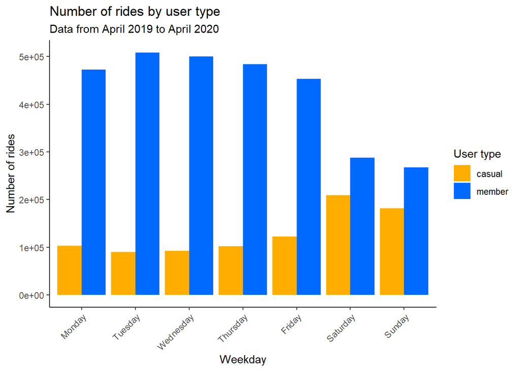

```r
ggplot(data = viz_data) + geom_col(mapping = aes(x= factor(day_of_week, level_order),
                                                 y = number_of_rides, fill = member_casual),
                                   position = "dodge") +
  theme_classic() +
  theme(axis.text.x = element_text(angle = 45, hjust=1)) +
  labs(title = "Number of rides by user type",
       subtitle = "Data from April 2019 to April 2020",
       x = "Weekday", y = "Number of rides") +
  guides(fill=guide_legend(title="User type")) +
  scale_fill_manual(values = c("#ffae00", "#006aff"))
```

```r
ggsave("number_of_rides_by_user_type.png") # saving visualization
```

**Now let’s visualize the average duration.**

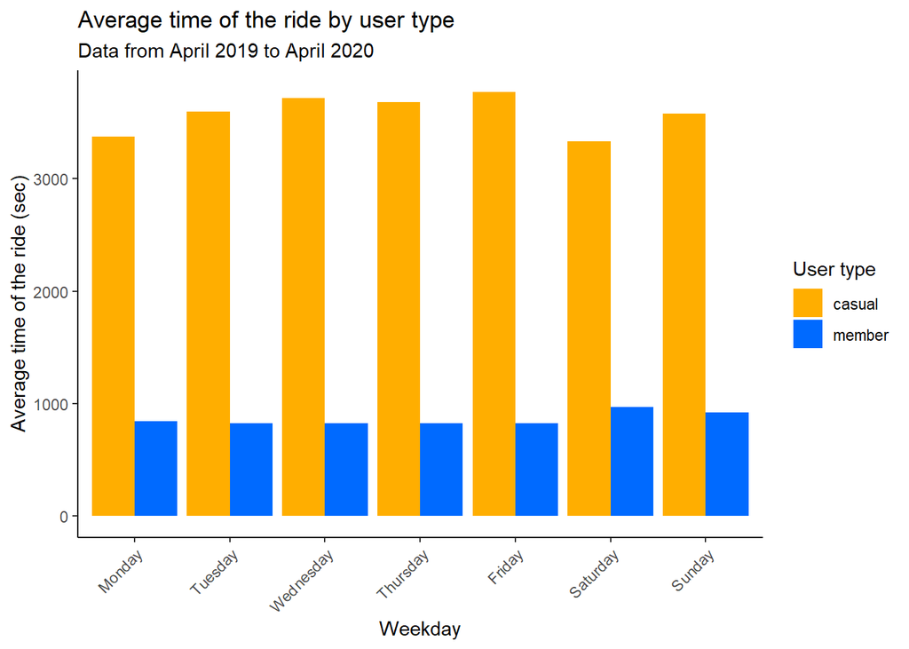

```r
ggplot(data = viz_data) + geom_col(mapping = aes(x= factor(day_of_week, level_order),
                                                 y = average_duration, fill = member_casual),
                                   position = "dodge") +
  theme_classic() +
  theme(axis.text.x = element_text(angle = 45, hjust=1)) +
  labs(title = "Average time of the ride by user type",
       subtitle = "Data from April 2019 to April 2020",
       x = "Weekday", y = "Average time of the ride (sec)") +
  guides(fill=guide_legend(title="User type")) +
  scale_fill_manual(values = c("#ffae00", "#006aff"))
```

```r
ggsave("average_time_of_the_ride_by_user_type.png") # saving visualization
```

Export files.

```r
counts <- aggregate(all_trips_v2$ride_length ~ all_trips_v2$member_casual +
                      all_trips_v2$day_of_week, FUN = mean)
write.csv(counts, file = '/Users/angel/Documents/Environmental/Data_Analytics/Case_Study/Case_Study_1/Case_Study_1_Data/avg_ride_length.csv')
write.csv(viz_data, file = '/Users/angel/Documents/Environmental/Data_Analytics/Case_Study/Case_Study_1/Case_Study_1_Data/viz_data.csv')
```

### Share and Act stages of data analysis

After completing data analysis and gaining insights we want to create a compelling presentation for our primal stakeholders - Lily Moreno and marketing team. We decided to do it in Google Slides. After outlining our main ideas on paper we created this [**presentation**](https://docs.google.com/presentation/d/11Ou_su6JIvc8ODL6qMclFeydToFz93hZvzIZIRML9M8/edit?usp=sharing)

Moreno and marketing team was satisfied with our work and have taken our recommendations into consideration.